# TP1

Vincent LE MEUR

2023-09-13

# TP1: STATISTIQUE EXPLORATOIRE MULTIDIMENSIONNELLE: Analyse en Composantes Principales Normées

# Exercice 2

## Utilisation de l’ACP? :

```r
library(readr)
eleves <- read_delim("Data_eleves (2).csv",
    delim = ";", escape_double = FALSE, locale = locale(decimal_mark = ","),
    trim_ws = TRUE)
View(eleves)
```

```r
summary(eleves)
```

```
##     eleves               ORTH            GRAM             EXPR
##  Length:27          Min.   : 0.00   Min.   : 2.000   Min.   : 2.000
##  Class :character   1st Qu.: 5.75   1st Qu.: 6.500   1st Qu.: 7.500
##  Mode  :character   Median :11.00   Median : 7.500   Median : 9.000
##                     Mean   :10.02   Mean   : 7.556   Mean   : 8.889
##                     3rd Qu.:14.00   3rd Qu.: 8.500   3rd Qu.:10.500
##                     Max.   :20.00   Max.   :14.500   Max.   :16.500
##       RECI            MATH            ANGL            HIST
##  Min.   : 4.00   Min.   : 8.00   Min.   : 3.00   Min.   : 5.000
##  1st Qu.: 6.50   1st Qu.:10.00   1st Qu.: 8.75   1st Qu.: 7.750
##  Median :10.00   Median :12.00   Median :11.00   Median : 9.000
##  Mean   :10.07   Mean   :12.57   Mean   :10.93   Mean   : 9.204
##  3rd Qu.:12.50   3rd Qu.:14.50   3rd Qu.:12.75   3rd Qu.:11.000
##  Max.   :16.00   Max.   :18.00   Max.   :17.00   Max.   :15.000
##       BIOL             EDMU            ARTS             TECH
##  Min.   : 2.000   Min.   : 7.00   Min.   : 1.500   Min.   : 0.00
##  1st Qu.: 7.000   1st Qu.:13.75   1st Qu.: 6.750   1st Qu.:11.50
##  Median :10.000   Median :16.00   Median : 9.000   Median :14.00
##  Mean   : 9.593   Mean   :15.20   Mean   : 9.019   Mean   :12.63
##  3rd Qu.:12.000   3rd Qu.:17.50   3rd Qu.:12.500   3rd Qu.:16.00
##  Max.   :17.000   Max.   :19.00   Max.   :14.500   Max.   :18.00
##       EPS             GEO             EXPO
##  Min.   : 5.00   Min.   : 0.00   Min.   : 0.00
##  1st Qu.:11.00   1st Qu.:13.00   1st Qu.:13.50
##  Median :13.50   Median :14.00   Median :15.00
##  Mean   :13.07   Mean   :13.80   Mean   :14.48
##  3rd Qu.:15.25   3rd Qu.:15.25   3rd Qu.:17.00
##  Max.   :18.50   Max.   :18.00   Max.   :18.00
```

### On n’observe pas de grandes différences entre les moyennes, on est donc pas obligé de faire une ACP normée sur ce modèle. Cependant nous allons quand même l’utiliser.

```r
eleves_2 <- eleves[,-1]
matcor <- cor(eleves_2)


library(Hmisc)
rcorr(as.matrix(eleves_2))
```

```
##       ORTH  GRAM EXPR  RECI  MATH  ANGL  HIST  BIOL EDMU  ARTS  TECH   EPS
## ORTH  1.00  0.53 0.51 -0.07  0.38  0.65  0.54  0.35 0.18  0.31 -0.29 -0.04
## GRAM  0.53  1.00 0.35 -0.10  0.34  0.40  0.30 -0.02 0.21  0.15 -0.17 -0.09
## EXPR  0.51  0.35 1.00  0.24  0.59  0.54  0.59  0.40 0.63  0.72  0.00  0.03
## RECI -0.07 -0.10 0.24  1.00  0.18 -0.04 -0.06  0.13 0.41  0.32  0.34  0.24
## MATH  0.38  0.34 0.59  0.18  1.00  0.70  0.64  0.12 0.28  0.37  0.21 -0.06
## ANGL  0.65  0.40 0.54 -0.04  0.70  1.00  0.59  0.17 0.00  0.29 -0.23 -0.27
## HIST  0.54  0.30 0.59 -0.06  0.64  0.59  1.00  0.26 0.22  0.26 -0.01  0.07
## BIOL  0.35 -0.02 0.40  0.13  0.12  0.17  0.26  1.00 0.46  0.58 -0.17  0.10
## EDMU  0.18  0.21 0.63  0.41  0.28  0.00  0.22  0.46 1.00  0.70  0.18  0.29
## ARTS  0.31  0.15 0.72  0.32  0.37  0.29  0.26  0.58 0.70  1.00 -0.05  0.07
## TECH -0.29 -0.17 0.00  0.34  0.21 -0.23 -0.01 -0.17 0.18 -0.05  1.00  0.07
## EPS  -0.04 -0.09 0.03  0.24 -0.06 -0.27  0.07  0.10 0.29  0.07  0.07  1.00
## GEO   0.16 -0.07 0.39 -0.11  0.33  0.13  0.33  0.46 0.32  0.24  0.15  0.35
## EXPO  0.14  0.05 0.31  0.33  0.41  0.25  0.26  0.56 0.43  0.57  0.29 -0.22
##        GEO  EXPO
## ORTH  0.16  0.14
## GRAM -0.07  0.05
## EXPR  0.39  0.31
## RECI -0.11  0.33
## MATH  0.33  0.41
## ANGL  0.13  0.25
## HIST  0.33  0.26
## BIOL  0.46  0.56
## EDMU  0.32  0.43
## ARTS  0.24  0.57
## TECH  0.15  0.29
## EPS   0.35 -0.22
## GEO   1.00  0.09
## EXPO  0.09  1.00
##
## n= 27
##
##
## P
##      ORTH   GRAM   EXPR   RECI   MATH   ANGL   HIST   BIOL   EDMU   ARTS
## ORTH        0.0043 0.0063 0.7442 0.0523 0.0002 0.0033 0.0732 0.3599 0.1188
## GRAM 0.0043        0.0700 0.6056 0.0816 0.0368 0.1351 0.9195 0.3046 0.4699
## EXPR 0.0063 0.0700        0.2356 0.0012 0.0038 0.0012 0.0378 0.0004 0.0000
## RECI 0.7442 0.6056 0.2356        0.3675 0.8375 0.7753 0.5032 0.0329 0.0982
```

[output cut: 10 more lines]

```
##      TECH   EPS    GEO    EXPO
## ORTH 0.1371 0.8445 0.4182 0.4777
## GRAM 0.4072 0.6384 0.7221 0.7937
## EXPR 0.9857 0.8961 0.0415 0.1099
## RECI 0.0819 0.2350 0.5819 0.0929
## MATH 0.2933 0.7653 0.0968 0.0332
## ANGL 0.2568 0.1676 0.5041 0.2018
## HIST 0.9418 0.7387 0.0939 0.1931
## BIOL 0.4107 0.6266 0.0151 0.0023
## EDMU 0.3798 0.1389 0.1014 0.0241
## ARTS 0.7893 0.7454 0.2287 0.0019
## TECH        0.7298 0.4414 0.1441
## EPS  0.7298        0.0761 0.2737
## GEO  0.4414 0.0761        0.6395
## EXPO 0.1441 0.2737 0.6395
```

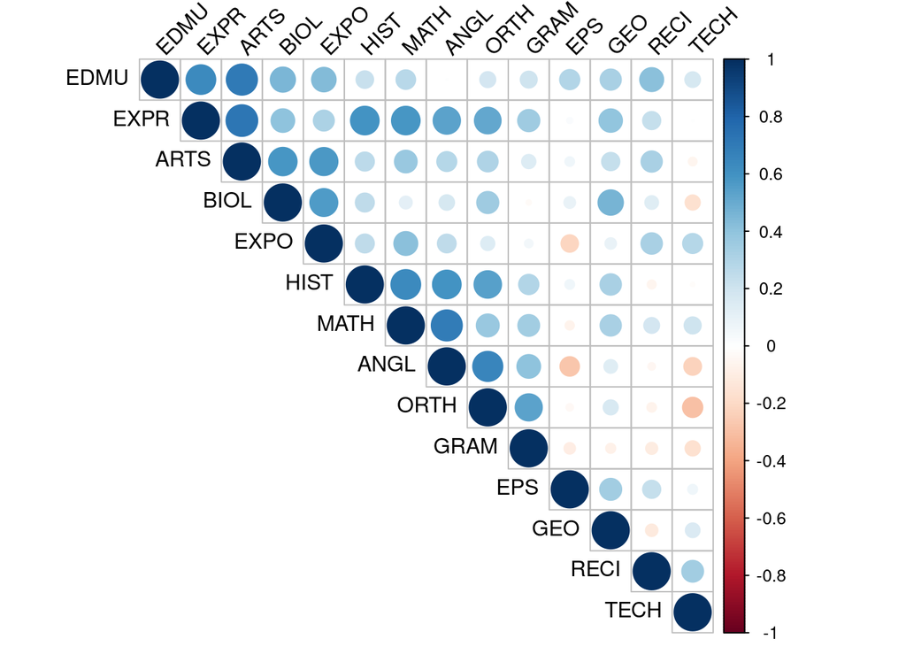

```r
library(corrplot)
corrplot(matcor, type="upper", order="hclust", tl.col="black", tl.srt=45)
```

### On peut observer que plusieurs matières sont corrélées positivement entre elles telles que l’anglais et les maths ou alors Art et l’Expr, on peut alors se permettre d’utiliser l’ACP.

## Composantes à garder

```r
library(FactoMineR)
library(factoextra)
```

```r
eleves_2.pca = PCA(eleves_2, scale.unit=TRUE,graph=FALSE)

eleves_2.pca$eig
```

```
##         eigenvalue percentage of variance cumulative percentage of variance
## comp 1  4.77570045             34.1121461                          34.11215
## comp 2  2.39238450             17.0884607                          51.20061
## comp 3  1.49934217             10.7095870                          61.91019
## comp 4  1.34084173              9.5774409                          71.48763
## comp 5  1.12670192              8.0478709                          79.53551
## comp 6  0.72038480              5.1456057                          84.68111
## comp 7  0.59919071              4.2799337                          88.96104
## comp 8  0.42748490              3.0534636                          92.01451
## comp 9  0.39040787              2.7886277                          94.80314
## comp 10 0.25931678              1.8522627                          96.65540
## comp 11 0.18210022              1.3007158                          97.95611
## comp 12 0.12552548              0.8966105                          98.85273
## comp 13 0.09728799              0.6949142                          99.54764
## comp 14 0.06333049              0.4523606                         100.00000
```

```r
eleves_2.pca$var
```

```
## $coord
##            Dim.1       Dim.2        Dim.3       Dim.4       Dim.5
## ORTH 0.650378590 -0.49271901  0.173647652 -0.10480943  0.14895341
## GRAM 0.417388795 -0.48575680 -0.071743415 -0.01051370  0.50581332
## EXPR 0.874166811  0.01540502  0.046797227  0.04371614  0.14884945
## RECI 0.247299110  0.59505913 -0.371423503  0.02016356  0.39197929
## MATH 0.733273680 -0.17286351 -0.306912714  0.42772948 -0.08498142
## ANGL 0.660960956 -0.58211516 -0.178752583  0.06388966 -0.09975141
## HIST 0.698144175 -0.30880357  0.072665513  0.34374243 -0.12739816
## BIOL 0.598226171  0.29312427  0.324794825 -0.44434410 -0.34799317
## EDMU 0.644856795  0.53510937  0.097359762 -0.09289748  0.29956935
## ARTS 0.758076081  0.33115891  0.006050377 -0.36129256  0.08037631
## TECH 0.009501976  0.51511927 -0.466209076  0.56544225 -0.12534130
## EPS  0.043328615  0.43201931  0.601812160  0.37873765  0.35484197
## GEO  0.447322427  0.22075833  0.540616973  0.38354653 -0.41420069
## EXPO 0.583734627  0.33551118 -0.453503335 -0.27451089 -0.33011273
##
## $cor
##            Dim.1       Dim.2        Dim.3       Dim.4       Dim.5
## ORTH 0.650378590 -0.49271901  0.173647652 -0.10480943  0.14895341
## GRAM 0.417388795 -0.48575680 -0.071743415 -0.01051370  0.50581332
## EXPR 0.874166811  0.01540502  0.046797227  0.04371614  0.14884945
## RECI 0.247299110  0.59505913 -0.371423503  0.02016356  0.39197929
## MATH 0.733273680 -0.17286351 -0.306912714  0.42772948 -0.08498142
## ANGL 0.660960956 -0.58211516 -0.178752583  0.06388966 -0.09975141
## HIST 0.698144175 -0.30880357  0.072665513  0.34374243 -0.12739816
## BIOL 0.598226171  0.29312427  0.324794825 -0.44434410 -0.34799317
## EDMU 0.644856795  0.53510937  0.097359762 -0.09289748  0.29956935
## ARTS 0.758076081  0.33115891  0.006050377 -0.36129256  0.08037631
## TECH 0.009501976  0.51511927 -0.466209076  0.56544225 -0.12534130
## EPS  0.043328615  0.43201931  0.601812160  0.37873765  0.35484197
## GEO  0.447322427  0.22075833  0.540616973  0.38354653 -0.41420069
## EXPO 0.583734627  0.33551118 -0.453503335 -0.27451089 -0.33011273
##
## $cos2
##             Dim.1        Dim.2        Dim.3        Dim.4       Dim.5
## ORTH 4.229923e-01 0.2427720217 3.015351e-02 0.0109850169 0.022187119
## GRAM 1.742134e-01 0.2359596680 5.147118e-03 0.0001105378 0.255847113
## EXPR 7.641676e-01 0.0002373146 2.189980e-03 0.0019111006 0.022156159
## RECI 6.115685e-02 0.3540953710 1.379554e-01 0.0004065693 0.153647766
```

[output cut: 12 more lines]

```
##             Dim.1        Dim.2        Dim.3        Dim.4      Dim.5
## ORTH  8.857178434 10.147700841  2.011115774  0.819262759  1.9692093
## GRAM  3.647913177  9.862949216  0.343291721  0.008243911 22.7076131
## EXPR 16.001163011  0.009919583  0.146062754  0.142529916  1.9664615
## RECI  1.280583878 14.800939040  9.201063052  0.030321946 13.6369489
## MATH 11.258878062  1.249038115  6.282449446 13.644601594  0.6409718
## ANGL  9.147755175 14.164029878  2.131100334  0.304427329  0.8831389
## HIST 10.205943479  3.985966555  0.352172894  8.812289759  1.4405132
## BIOL  7.493655757  3.591472838  7.035864125 14.725203802 10.7481175
## EDMU  8.707419780 11.968896845  0.632205474  0.643621144  7.9649991
## ARTS 12.033404324  4.583971428  0.002441541  9.735102286  0.5733860
## TECH  0.001890561 11.091355234 14.496417584 23.845091334  1.3943743
## EPS   0.039310859  7.801449997 24.155785266 10.697922436 11.1753449
## GEO   4.189905868  2.037057095 19.492996119 10.971312784 15.2269386
## EXPO  7.134997636  4.705253336 13.717033917  5.620069002  9.6719828
```

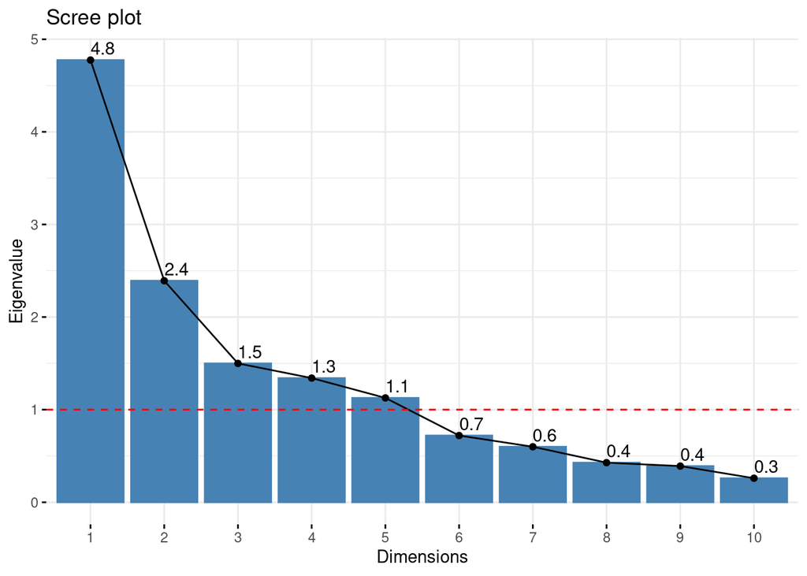

```r
fviz_eig(eleves_2.pca,choice = "eigenvalue", addlabels = TRUE )+
geom_hline (yintercept = 1, linetype = 2, color = "red")
```

### Avec le critère du coude sur le graphique on peut alors retenir que 3 composantes. En effet ce phénomène peut être observé au moment où la pente devient moins raide sur le graphique. De plus en observant le pourcentage cumulé de la variance on peut oberver que les 3 première valeurs suffisent (ici on décide d’aller jusqu’à 60%)

## Analyse

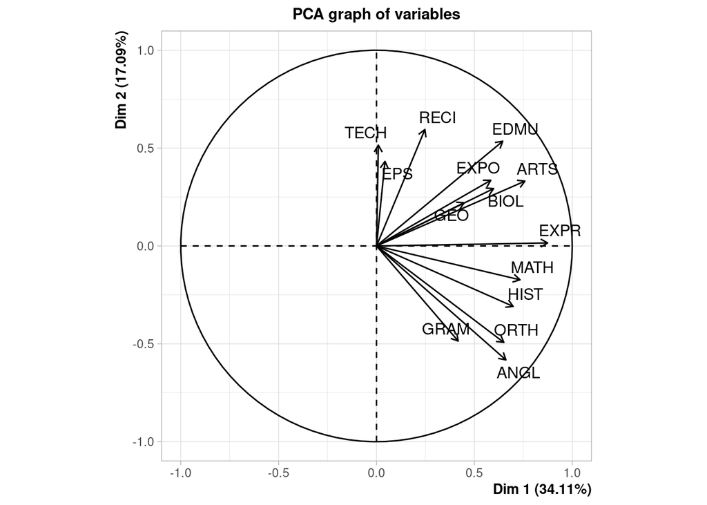

```r
library(plotly)
plot.PCA(eleves_2.pca, axes=c(1,2), choix="var")
```

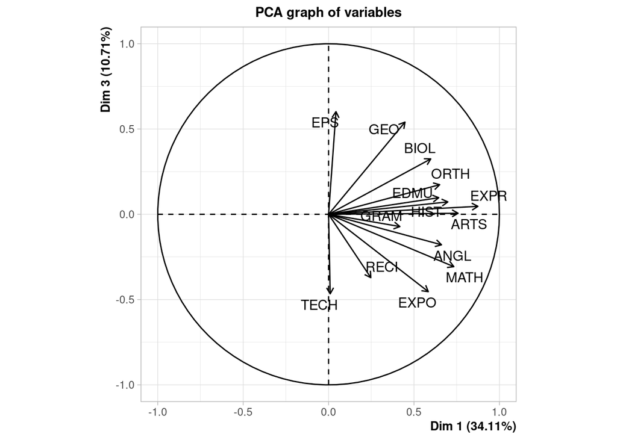

```r
plot.PCA(eleves_2.pca, axes=c(1,3), choix="var")
```

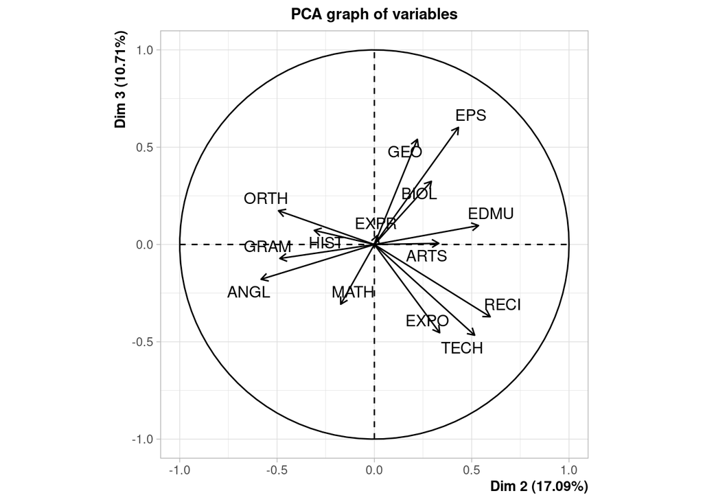

```r
plot.PCA(eleves_2.pca, axes=c(2,3), choix="var")
```

```r
eleves_2.pca$var
```

```
## $coord
##            Dim.1       Dim.2        Dim.3       Dim.4       Dim.5
## ORTH 0.650378590 -0.49271901  0.173647652 -0.10480943  0.14895341
## GRAM 0.417388795 -0.48575680 -0.071743415 -0.01051370  0.50581332
## EXPR 0.874166811  0.01540502  0.046797227  0.04371614  0.14884945
## RECI 0.247299110  0.59505913 -0.371423503  0.02016356  0.39197929
## MATH 0.733273680 -0.17286351 -0.306912714  0.42772948 -0.08498142
## ANGL 0.660960956 -0.58211516 -0.178752583  0.06388966 -0.09975141
## HIST 0.698144175 -0.30880357  0.072665513  0.34374243 -0.12739816
## BIOL 0.598226171  0.29312427  0.324794825 -0.44434410 -0.34799317
## EDMU 0.644856795  0.53510937  0.097359762 -0.09289748  0.29956935
## ARTS 0.758076081  0.33115891  0.006050377 -0.36129256  0.08037631
## TECH 0.009501976  0.51511927 -0.466209076  0.56544225 -0.12534130
## EPS  0.043328615  0.43201931  0.601812160  0.37873765  0.35484197
## GEO  0.447322427  0.22075833  0.540616973  0.38354653 -0.41420069
## EXPO 0.583734627  0.33551118 -0.453503335 -0.27451089 -0.33011273
##
## $cor
##            Dim.1       Dim.2        Dim.3       Dim.4       Dim.5
## ORTH 0.650378590 -0.49271901  0.173647652 -0.10480943  0.14895341
## GRAM 0.417388795 -0.48575680 -0.071743415 -0.01051370  0.50581332
## EXPR 0.874166811  0.01540502  0.046797227  0.04371614  0.14884945
## RECI 0.247299110  0.59505913 -0.371423503  0.02016356  0.39197929
## MATH 0.733273680 -0.17286351 -0.306912714  0.42772948 -0.08498142
## ANGL 0.660960956 -0.58211516 -0.178752583  0.06388966 -0.09975141
## HIST 0.698144175 -0.30880357  0.072665513  0.34374243 -0.12739816
## BIOL 0.598226171  0.29312427  0.324794825 -0.44434410 -0.34799317
## EDMU 0.644856795  0.53510937  0.097359762 -0.09289748  0.29956935
## ARTS 0.758076081  0.33115891  0.006050377 -0.36129256  0.08037631
## TECH 0.009501976  0.51511927 -0.466209076  0.56544225 -0.12534130
## EPS  0.043328615  0.43201931  0.601812160  0.37873765  0.35484197
## GEO  0.447322427  0.22075833  0.540616973  0.38354653 -0.41420069
## EXPO 0.583734627  0.33551118 -0.453503335 -0.27451089 -0.33011273
##
## $cos2
##             Dim.1        Dim.2        Dim.3        Dim.4       Dim.5
## ORTH 4.229923e-01 0.2427720217 3.015351e-02 0.0109850169 0.022187119
## GRAM 1.742134e-01 0.2359596680 5.147118e-03 0.0001105378 0.255847113
## EXPR 7.641676e-01 0.0002373146 2.189980e-03 0.0019111006 0.022156159
## RECI 6.115685e-02 0.3540953710 1.379554e-01 0.0004065693 0.153647766
```

[output cut: 12 more lines]

```
##             Dim.1        Dim.2        Dim.3        Dim.4      Dim.5
## ORTH  8.857178434 10.147700841  2.011115774  0.819262759  1.9692093
## GRAM  3.647913177  9.862949216  0.343291721  0.008243911 22.7076131
## EXPR 16.001163011  0.009919583  0.146062754  0.142529916  1.9664615
## RECI  1.280583878 14.800939040  9.201063052  0.030321946 13.6369489
## MATH 11.258878062  1.249038115  6.282449446 13.644601594  0.6409718
## ANGL  9.147755175 14.164029878  2.131100334  0.304427329  0.8831389
## HIST 10.205943479  3.985966555  0.352172894  8.812289759  1.4405132
## BIOL  7.493655757  3.591472838  7.035864125 14.725203802 10.7481175
## EDMU  8.707419780 11.968896845  0.632205474  0.643621144  7.9649991
## ARTS 12.033404324  4.583971428  0.002441541  9.735102286  0.5733860
## TECH  0.001890561 11.091355234 14.496417584 23.845091334  1.3943743
## EPS   0.039310859  7.801449997 24.155785266 10.697922436 11.1753449
## GEO   4.189905868  2.037057095 19.492996119 10.971312784 15.2269386
## EXPO  7.134997636  4.705253336 13.717033917  5.620069002  9.6719828
```

### On observe que la première dimension explique très bien EXPR, MATH et ARTS qui ont une forte contribution et qui sont corrélés entre elles.Et sont corrélés dans le même sens (sens positif).

### De même pour la dimension 2 il y a une forte contribution de ANGL et et RECIT.

### Pour finir pour la 3 eme dimension on observe que EPS est fortement représenté puis est suivi par TECH et GEO.

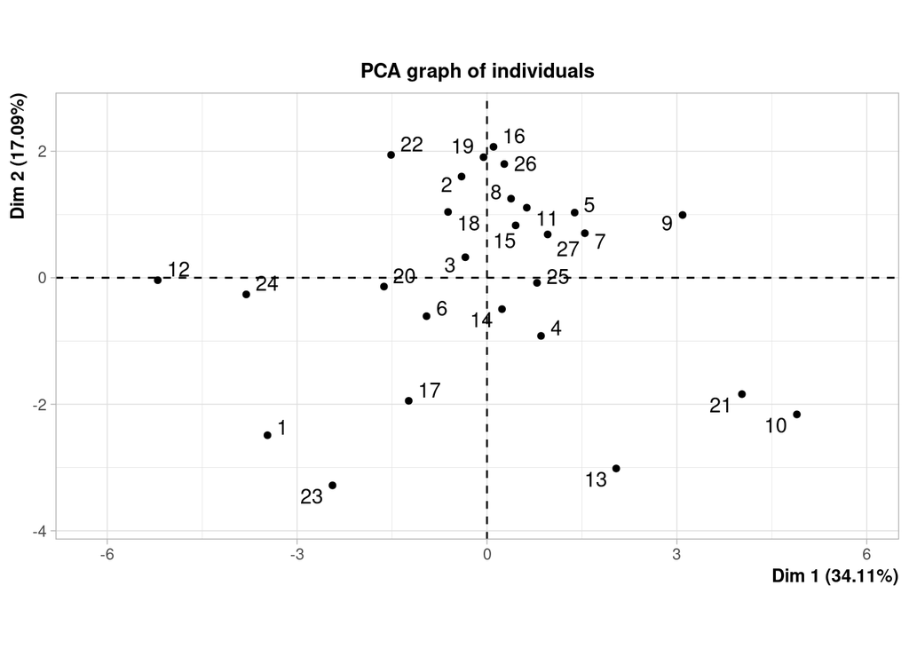

```r
library(plotly)
plot.PCA(eleves_2.pca, axes=c(1,2), choix="ind",label='ind')
```

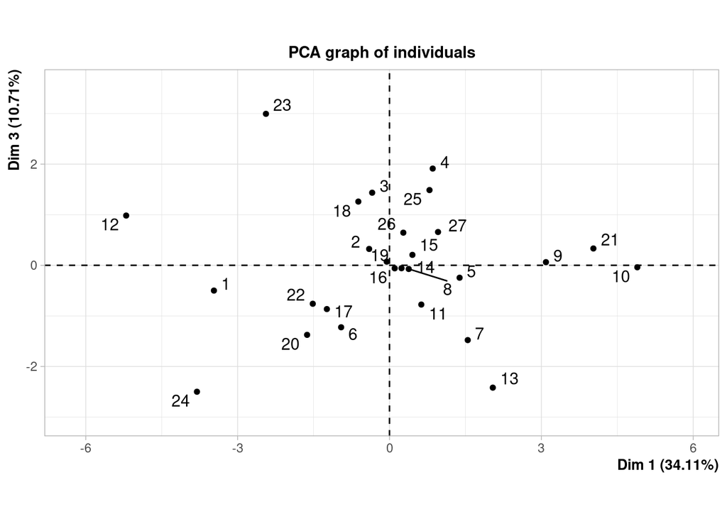

```r
plot.PCA(eleves_2.pca, axes=c(1,3), choix="ind",label='ind')
```

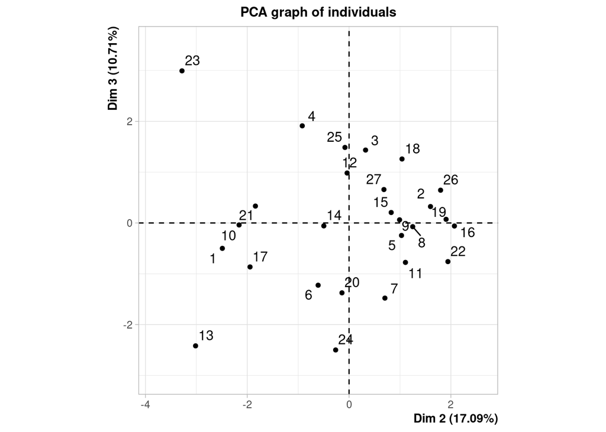

```r
plot.PCA(eleves_2.pca, axes=c(2,3), choix="ind",label='ind')
```

```r
eleves_2.pca$ind
```

```
## $coord
##          Dim.1       Dim.2       Dim.3       Dim.4       Dim.5
## 1  -3.46829286 -2.48905999 -0.49957922 -0.25311118 -0.70752120
## 2  -0.40191364  1.59959535  0.32345688  2.12961303  0.55734015
## 3  -0.34236081  0.32431321  1.43507459  0.34376495  0.36094107
## 4   0.85381133 -0.91935307  1.91208115 -2.75008233 -1.13000180
## 5   1.38506473  1.03014005 -0.24547556 -0.33046869  0.22643087
## 6  -0.95508698 -0.60747266 -1.22508238  1.15938901 -0.98668811
## 7   1.54604173  0.70394630 -1.47838488  0.76257176 -0.03404613
## 8   0.38010204  1.25010046 -0.07265920 -0.20194924 -1.28114818
## 9   3.09058348  0.99216038  0.06237004  0.42533512  0.51023530
## 10  4.89577183 -2.16036642 -0.03871588  0.98136354  1.66102013
## 11  0.62866206  1.10747236 -0.77589172  0.74472643 -0.53960637
## 12 -5.20192545 -0.03860811  0.98309591  1.68562562  0.37433423
## 13  2.04130576 -3.01489363 -2.41830474  0.27125287  0.05004161
```

[output cut: 84 more lines]